# 시험장 환경 정보

## 단계 1-3

일별 기준(DateHour 변수 사용)으로 시간당 최대수요전력 합계(TotalHour) 의

범위(최대값-최소값)가 가장 큰 값을 찾고

이 값을 D라고 한다.

```python
# 방법 1: groupby ~ agg
D = df_basetable1.groupby(df_basetable1.index.date)['TotalHour'].agg(lambda x: x.max() - x.min()).max()
D
```

```
706
```

```python
# 방법 2: groupby ~ apply
# apply의 N:1 집계 연산을 통해서도 가능합니다.
D = df_basetable1.groupby(df_basetable1.index.date)['TotalHour'].apply(lambda x: x.max() - x.min()).max()
D
```

```
706
```

## 단계 1-4

공휴일과 주말을 제외한 평일 데이터만 추출을 한 후,

일별 기준으로 시간당 최대수요전력 합계(TotalHour)의 범위(최대값-최소값)가

가장 큰 일자의 요일명(DayName)을 E라고 한다.

```python
# 예제 코드

data = {'Age' : [1, 2, 3, 4],
       'Score' : [1, 1, 6, 7]}
df = pd.DataFrame(data)
df
```

|  | Age | Score |
| --- | --- | --- |
| 0 | 1 | 1 |
| 1 | 2 | 1 |
| 2 | 3 | 6 |
| 3 | 4 | 7 |

```python
df[['Age', 'Score']] == 1
```

|  | Age | Score |
| --- | --- | --- |
| 0 | True | True |
| 1 | False | True |
| 2 | False | False |
| 3 | False | False |

```python
(df[['Age', 'Score']] == 1).any(axis = 1) #행 단위
```

```
0     True
1     True
2    False
3    False
dtype: bool
```

```python
(df[['Age', 'Score']] == 1).all(axis = 1) #행 단위
```

```
0     True
1    False
2    False
3    False
dtype: bool
```

```python
(df[['Age', 'Score']] == 1).any(axis = 0) #열 단위
```

```
Age      True
Score    True
dtype: bool
```

```python
(df[['Age', 'Score']] == 1).all(axis = 0) #열 단위
```

```
Age      False
Score    False
dtype: bool
```

```python
'''
1. 조건에 맞는 행 선택:
   df_tmp = df_basetable1.loc[
       ~(df_basetable1[['Weekend_yn', 'Holiday_yn']] == 1).any(axis=1)
   ]
   - `df_basetable1[['Weekend_yn', 'Holiday_yn']] == 1`는 'Weekend_yn' 또는
       'Holiday_yn'이 1인 행들을 `True`로 표시하는 불리언 데이터프레임을 만듭니다.
   - `.any(axis=1)`는 행 단위로 `True` 값이 하나라도 있으면 `True`를 반환하는 불리언 시리즈를 만듭니다.
   - `~`는 이 불리언 시리즈의 값을 반전시켜 'Weekend_yn'과 'Holiday_yn'이 모두 1이 아닌 행들을 선택합니다.
   - `df_basetable1.loc[...]`는 이 불리언 시리즈를 이용해 해당 행들을 선택합니다.

2. 그룹화 및 계산:
   E = df_tmp.groupby(df_tmp.index.date)['TotalHour'].apply(lambda x: x.max() - x.min()).idxmax().weekday()
   - `df_tmp.groupby(df_tmp.index.date)`는 날짜별로 그룹화합니다.
   - `['TotalHour']`는 'TotalHour' 열을 선택합니다.
   - `.apply(lambda x: x.max() - x.min())`는 각 그룹에서 'TotalHour'의 최댓값과 최솟값의 차이를 계산합니다.
   - `.idxmax()`는 차이가 가장 큰 그룹의 인덱스를 반환합니다.
   - `.weekday()`는 그 인덱스의 요일을 반환합니다.
'''

# 방법 1: 중간 결과를 임시테이블에 저장합니다.
df_tmp = df_basetable1.loc[
    ~(df_basetable1[['Weekend_yn', 'Holiday_yn']] == 1).any(axis=1)
]

E = df_tmp.groupby(df_tmp.index.date)['TotalHour'].apply(lambda x: x.max() - x.min()).idxmax().weekday()

E
```

```
0
```

```python
df_basetable1.loc[
    ~(df_basetable1[['Weekend_yn', 'Holiday_yn']] == 1).any(axis=1)
]
```

| DateHour | 15분 | 30분 | 45분 | 60분 | DayName | Hour | AM | Weekend_yn | Holiday_yn | Avg | TotalHour | 생산량 | 기온 | 풍속 | 습도 | 강수량 | 전기요금(계절) | 공장인원 | 인건비 |
| --- | --- | --- | --- | --- | --- | --- | --- | --- | --- | --- | --- | --- | --- | --- | --- | --- | --- | --- | --- |
| 2021-01-04 00:00:00 | 72 | 67 | 66 | 66 | 0 | 0 | 0 | 0 | 0 | 67.75 | 271 | 0 | -0.1 | 1.7 | 39 | 0.0 | 109.8 | 0.000000 | 1.5 |
| 2021-01-04 01:00:00 | 96 | 108 | 119 | 109 | 0 | 1 | 0 | 0 | 0 | 108.00 | 432 | 0 | -0.9 | 1.3 | 44 | 0.0 | 109.8 | 0.000000 | 1.5 |
| 2021-01-04 02:00:00 | 106 | 106 | 111 | 116 | 0 | 2 | 0 | 0 | 0 | 109.75 | 439 | 0 | -0.4 | 1.4 | 42 | 0.0 | 109.8 | 0.000000 | 1.5 |
| 2021-01-04 03:00:00 | 104 | 105 | 104 | 113 | 0 | 3 | 0 | 0 | 0 | 106.50 | 426 | 0 | -2.1 | 1.5 | 50 | 0.0 | 109.8 | 0.000000 | 1.5 |
| 2021-01-04 04:00:00 | 115 | 109 | 108 | 103 | 0 | 4 | 0 | 0 | 0 | 108.75 | 435 | 0 | -1.9 | 1.8 | 50 | 0.0 | 109.8 | 0.000000 | 1.5 |
| ... | ... | ... | ... | ... | ... | ... | ... | ... | ... | ... | ... | ... | ... | ... | ... | ... | ... | ... | ... |
| 2021-09-14 19:00:00 | 152 | 151 | 171 | 139 | 1 | 19 | 1 | 0 | 0 | 153.25 | 613 | 1497 | 21.7 | 3.6 | 85 | 9.4 | 167.2 | 2.442088 | 1.5 |
| 2021-09-14 20:00:00 | 124 | 130 | 128 | 130 | 1 | 20 | 1 | 0 | 0 | 128.00 | 512 | 45 | 22.2 | 4.2 | 78 | 9.4 | 167.2 | 0.087891 | 1.5 |
| 2021-09-14 21:00:00 | 134 | 130 | 125 | 124 | 1 | 21 | 1 | 0 | 0 | 128.25 | 513 | 149 | 22.2 | 4.3 | 76 | 9.4 | 167.2 | 0.290448 | 1.5 |
| 2021-09-14 22:00:00 | 100 | 109 | 120 | 114 | 1 | 22 | 1 | 0 | 0 | 110.75 | 443 | 66 | 22.0 | 2.5 | 79 | 9.4 | 167.2 | 0.148984 | 1.5 |
| 2021-09-14 23:00:00 | 117 | 119 | 112 | 91 | 1 | 23 | 1 | 0 | 0 | 109.75 | 439 | 405 | 22.0 | 2.5 | 79 | 9.4 | 167.2 | 0.922551 | 1.5 |

4224 rows × 19 columns

```python
'''
1. 조건에 맞는 행 선택:
   df_basetable1.loc[
       ~(df_basetable1[['Weekend_yn', 'Holiday_yn']] == 1).any(axis=1)
   ]
   - 이 부분은 첫 번째 코드와 동일합니다.

2. `pipe`를 이용한 연산:
   .pipe(
       lambda x: x.groupby(x.index.date)['TotalHour']
           .apply(lambda x: x.max() - x.min()).idxmax().weekday()
   )
   - `.pipe()`는 데이터프레임을 인자로 받아 다른 함수에 전달합니다. 이를 통해 메소드 체이닝을 깔끔하게 유지할 수 있습니다.
   - `lambda x: x.groupby(x.index.date)['TotalHour']
           .apply(lambda x: x.max() - x.min()).idxmax().weekday()`는 첫 번째 코드의 두 번째 부분과 동일한 연산을 수행합니다.
'''

# 방법 2: pipe를 통해 연산을 이어갑니다.
E = df_basetable1.loc[
    ~(df_basetable1[['Weekend_yn', 'Holiday_yn']] == 1).any(axis=1)
].pipe(
    lambda x: x.groupby(x.index.date)['TotalHour'].apply(lambda x: x.max() - x.min()).idxmax().weekday()
)

E
```

```
0
```

```python
'''
위의 두 코드 조각은 최종적으로 동일한 결과를 반환하지만, 그 접근 방식이 다릅니다.
차이점은 코드의 가독성과 연쇄 메소드 호출 방식에 있습니다.

### 차이점 비교
1. 코드 구조와 가독성:
   - 첫 번째 코드 조각은 중간 변수 `df_tmp`를 사용하여 조건에 맞는 행을 선택하고, 그 다음 단계에서 그룹화와 계산을 수행합니다.
       중간 변수를 사용하여 코드의 각 단계를 명확하게 분리합니다.
   - 두 번째 코드 조각은 `pipe` 메소드를 사용하여 메소드 체이닝을 통해 한 줄로 연결된 형태로 작성되어 있습니다.
       `pipe`를 사용하면 중간 변수를 생략하고, 코드가 더 간결해집니다. 그러나 복잡한 로직에서는 가독성이 떨어질 수 있습니다.
2. 연산 과정:
   - 두 코드 조각은 기능적으로 동일한 연산을 수행합니다. 조건에 맞는 행을 선택하고,
       날짜별로 'TotalHour'의 최댓값과 최솟값의 차이를 계산하여, 그 차이가 가장 큰 날짜의 요일을 반환합니다.
3. 유연성:
   - 첫 번째 방법은 각 단계를 명확하게 나누기 때문에 디버깅이나 개별 단계의 수정이 용이합니다.
   - 두 번째 방법은 `pipe`를 통해 연속적인 메소드 호출을 가능하게 하여 코드가 더 간결해지고, 함수형 프로그래밍 스타일을 따릅니다.

### 요약
- 첫 번째 코드 조각: 중간 변수를 사용하여 각 단계를 명확하게 분리하고, 가독성을 높입니다.
- 두 번째 코드 조각: `pipe`를 사용하여 메소드 체이닝을 통해 코드를 간결하게 유지하며, 함수형 프로그래밍 스타일을 구현합니다.
'''
print('')
```

```python
# 방법 2-2: idxmax를 모르고 있다면 생각해볼수 있는 방법
E = df_basetable1.loc[
    ~(df_basetable1[['Weekend_yn', 'Holiday_yn']] == 1).any(axis=1)
].pipe(
    lambda x: x.groupby(x.index.date)['TotalHour'].apply(lambda x: x.max() - x.min())
).pipe(
    lambda x: x.loc[x == x.max()].index.values[0].weekday()
)

E
```

```
0
```

```python
# 방법 2와 방법 2-2의 비교
'''
1. 첫 번째 `pipe`:
   .pipe(
       lambda x: x.groupby(x.index.date)['TotalHour']
           .apply(lambda x: x.max() - x.min())
   )
   - 날짜별로 그룹화하여 각 날짜의 'TotalHour'의 최댓값과 최솟값의 차이를 계산합니다.
   - 이 결과는 각 날짜에 대해 최댓값과 최솟값의 차이를 담은 시리즈입니다.

2. 두 번째 `pipe`:
   .pipe(
       lambda x: x.loc[x == x.max()].index.values[0].weekday()
   )
   - `x == x.max()`는 최댓값을 가진 날짜를 찾습니다.
   - `loc[x == x.max()]`는 최댓값을 가진 날짜의 인덱스를 선택합니다.
   - `index.values[0].weekday()`는 그 인덱스의 첫 번째 값의 요일을 반환합니다.

### 차이점 비교
1. 중간 결과 처리:
   - 첫 번째 코드 조각에서는 그룹화된 결과에서 바로 `idxmax()`를 사용하여 최댓값의 인덱스를 찾고, 그 인덱스의 요일을 반환합니다.
   - 두 번째 코드 조각에서는 두 개의 `pipe`를 사용하여 중간 결과를 먼저 계산하고, 그 중 최댓값을 가진 인덱스를 찾아서 요일을 반환합니다.
2. 가독성:
   - 첫 번째 코드 조각은 더 간결하며, 연산을 한 줄로 연결하여 읽기 쉽습니다.
   - 두 번째 코드 조각은 중간 결과를 명확히 분리하여 각 단계를 구체적으로 나타내지만, 다소 복잡해 보일 수 있습니다.
3. 유연성:
   - 두 번째 코드 조각은 중간 결과를 명시적으로 처리하기 때문에, 중간 결과를 확인하거나 디버깅할 때 더 유리합니다.
   - 첫 번째 코드 조각은 중간 변수를 사용하지 않기 때문에 코드가 더 간결하지만, 디버깅 시 중간 결과를 확인하기 어렵습니다.
'''
print('')
```

```python
A, B, C, D, E, A + B + C + D + E
```

```
(830, 8, 11, 706, 0, 1555)
```

A + B + C + D + E를 적으시오.

# 문제 2

최대수요전력 평균(Avg) 값이 오전/오후에 따라 차이가 있는지 검정하시오.

## 단계 2-1

basetable1 에서 공휴일과 주말을 제외하고 prob2 데이터프레임을 만든다.

- prob2에서 시간(Hour)이 8과 11사이 (8, 11 포함) 또는 13과 16 (13, 16 포함) 사이의 행들만 남긴다.
- prob2에서 Avg가 130이상인 행들만을 남긴다.

Hint] 최종 1233개 행만 남는다.

```python
'''
`pandas`의 `query()` 함수는 DataFrame에 대해 문자열 표현식을 사용하여 행을 필터링할 수 있는 편리한 방법을 제공합니다.
이 함수는 특히 복잡한 조건을 사용할 때 코드 가독성을 높이고 작성하기 쉽게 해줍니다.

### `query()` 함수의 구문
DataFrame.query(expr, inplace=False, kwargs)

### 매개변수
1. `expr` (str):
    - 필터링 조건을 나타내는 문자열 표현식입니다. 표현식 내에서 DataFrame의 열 이름을 직접 사용하여 조건을 지정할 수 있습니다.

2. `inplace` (bool, default False):
    - `True`로 설정하면 원본 DataFrame을 변경합니다. `False`인 경우 필터링된 새로운 DataFrame을 반환합니다.

3. `kwargs`:
    - 다른 매개변수들을 포함할 수 있으며, 대부분의 경우에는 `query()`에서 사용할 수 있는 로컬 변수나 글로벌 변수를 전달하는 데 사용됩니다.

### 리턴값
- 기본적으로 `query()`는 필터링된 새로운 DataFrame을 반환합니다.
    `inplace=True`로 설정된 경우에는 `None`을 반환하고 원본 DataFrame이 수정됩니다.

### 사용 예시

1. 기본 사용법
import pandas as pd

# 예제 DataFrame 생성
data = {
    'name': ['Alice', 'Bob', 'Charlie', 'David'],
    'age': [24, 27, 22, 32],
    'score': [85, 62, 74, 91]
}
df = pd.DataFrame(data)

# query() 함수 사용
filtered_df = df.query('age > 25')
print(filtered_df)

결과:
   name  age  score
1   Bob   27     62
3 David   32     91

2. 복잡한 조건 사용
# 두 개의 조건을 사용하는 예제
filtered_df = df.query('age > 25 and score > 70')
print(filtered_df)

결과:
   name  age  score
3 David   32     91

3. 변수 사용
# 외부 변수를 사용하는 예제
age_threshold = 25
score_threshold = 70

filtered_df = df.query('age > @age_threshold and score > @score_threshold')
print(filtered_df)

결과:
   name  age  score
3 David   32     91

4. inplace 사용
# inplace=True를 사용하는 예제
df.query('age > 25', inplace=True)
print(df)

결과:
    name  age  score
1   Bob   27     62
3 David   32     91

5. 열 이름에 공백이나 특수문자가 있는 경우
# 열 이름에 공백이나 특수문자가 있는 경우 backticks(`)을 사용
df = pd.DataFrame({
    'user name': ['Alice', 'Bob', 'Charlie', 'David'],
    'user age': [24, 27, 22, 32],
    'user score': [85, 62, 74, 91]
})

filtered_df = df.query('`user age` > 25 and `user score` > 70')
print(filtered_df)

결과:
   user name  user age  user score
3      David        32          91

### 요약

- `query()` 함수는 DataFrame을 필터링할 때 문자열 표현식을 사용하여 조건을 지정할 수 있습니다.
- 기본 매개변수는 `expr` (필터링 조건 표현식), `inplace` (기존 DataFrame을 수정할지 여부)이며,
    `kwargs`로 다른 변수들을 전달할 수 있습니다.
- 반환값은 기본적으로 필터링된 새로운 DataFrame이며, `inplace=True`로 설정된 경우에는 `None`을 반환합니다.
- 외부 변수나 공백이 포함된 열 이름도 사용할 수 있습니다.
    외부 변수는 `@` 기호를 사용하여 참조하고, 공백이 포함된 열 이름은 backticks(``)을 사용하여 참조합니다.
'''

'''
이 코드는 두 부분으로 나누어 설명할 수 있습니다.
첫 번째 부분은 특정 조건을 만족하는 행을 선택하고, 두 번째 부분은 추가적인 조건을 만족하는 행을 선택합니다.

### 첫 번째 부분: 특정 조건을 만족하는 행 선택
df_prob2 = df_basetable1.loc[
    (df_basetable1[['Weekend_yn', 'Holiday_yn']] == 0).all(axis=1)
]
1. 조건 설정:
   (df_basetable1[['Weekend_yn', 'Holiday_yn']] == 0)
   - `df_basetable1[['Weekend_yn', 'Holiday_yn']]`는 데이터프레임 `df_basetable1`에서
       `Weekend_yn`과 `Holiday_yn` 열을 선택합니다.
   - `== 0`는 각 행의 `Weekend_yn`과 `Holiday_yn` 값이 0인지 확인합니다.
       결과는 `True` 또는 `False` 값을 가지는 데이터프레임이 됩니다.
2. 모든 조건 만족 여부 확인:
   .all(axis=1)
   - `all(axis=1)`는 각 행(row)에 대해 모든 조건이 `True`인지를 확인합니다.
       모든 조건이 `True`이면 `True`를 반환하고, 하나라도 `False`이면 `False`를 반환합니다.
3. 조건을 만족하는 행 선택:
   df_basetable1.loc[...]
   - `loc`는 조건이 `True`인 행을 선택합니다.
   - 결과적으로, `Weekend_yn`과 `Holiday_yn` 열의 값이 모두 0인 행들만 선택됩니다.

### 두 번째 부분: 추가 조건을 만족하는 행 선택
df_prob2 = df_prob2.query('((Hour >= 8 and Hour <= 11) or (Hour >= 13 and Hour <= 16)) and Avg >= 130')
1. 조건 설정:
   '((Hour >= 8 and Hour <= 11) or (Hour >= 13 and Hour <= 16)) and Avg >= 130'
   - 이 문자열은 쿼리 조건을 나타냅니다.
   - `(Hour >= 8 and Hour <= 11)`는 `Hour` 값이 8 이상 11 이하인 행을 선택합니다.
   - `(Hour >= 13 and Hour <= 16)`는 `Hour` 값이 13 이상 16 이하인 행을 선택합니다.
   - 두 조건은 `or` 연산자로 결합되어 있어, `Hour` 값이 8~11 또는 13~16 사이에 있는 행을 선택합니다.
   - `and Avg >= 130`는 `Avg` 값이 130 이상인 행을 선택합니다.
   - 전체 조건은 `Hour` 값이 8~11 또는 13~16 사이이고, 동시에 `Avg` 값이 130 이상인 행을 선택합니다.
2. 조건을 만족하는 행 선택:
   df_prob2.query(...)
   - `query` 메소드는 주어진 조건을 만족하는 행을 선택합니다.
   - 결과적으로, `df_prob2`는 `Hour` 값이 8~11 또는 13~16 사이이고, `Avg` 값이 130 이상인 행들만 포함하게 됩니다.

### 전체 코드 동작 요약
1. 첫 번째 부분:
   - `df_basetable1`에서 `Weekend_yn`과 `Holiday_yn` 값이 모두 0인 행을 선택합니다.
   - 즉, 주말이 아니고 공휴일이 아닌 날의 데이터를 선택합니다.
2. 두 번째 부분:
   - 선택된 데이터 중 `Hour` 값이 8~11 또는 13~16 사이이고, `Avg` 값이 130 이상인 행을 추가로 선택합니다.

최종적으로, `df_prob2`는 주말이 아니고 공휴일이 아닌 날 중에서 특정 시간대(8~11 또는 13~16)와
`Avg` 값이 130 이상인 데이터를 포함하는 데이터프레임이 됩니다.
'''

# 방법 1: query: 조건을 컬럼명으로만 표현할 수 있다면 유용한 방법입니다.
df_prob2 = df_basetable1.loc[
    (df_basetable1[['Weekend_yn', 'Holiday_yn']] == 0).all(axis=1)
]

df_prob2 = df_prob2.query('((Hour >= 8 and Hour <= 11) or \
                          (Hour >= 13 and Hour <= 16)) and Avg >= 130')
len(df_prob2)
```

```
1233
```

```python
# 방법 2: Boolean Indexing - 조건을 컬럼명으로 표현할 수 없을 경우에
# 논리 연산을 통해 구현합니다.
df_prob2 = df_basetable1.loc[
    (df_basetable1[['Weekend_yn', 'Holiday_yn']] == 0).all(axis=1)
]
df_prob2 = df_prob2.loc[
    (
        ((df_prob2['Hour'] >= 8) & (df_prob2['Hour'] <= 11)) |
        ((df_prob2['Hour'] >= 13) & (df_prob2['Hour'] <= 16))
    ) & (df_prob2['Avg'] >= 130)
]
len(df_prob2)
```

```
1233
```

```python
# 방법 2-2: Boolean Indexing + between - between 메소드를 통해
# 사이에 해당하는 조건을 간소화합니다.
df_prob2 = df_prob2.loc[
    (
        df_prob2['Hour'].between(8, 11, inclusive=True) |
        df_prob2['Hour'].between(13, 16, inclusive=True)
    ) & (df_prob2['Avg'] >= 130)
]
len(df_prob2)
```

```
1233
```

## 단계 2-2

오전(AM = 0) 인 행들을 대상으로 Avg에 대하여 Shapiro-Wilk 검정을 사용하여 정규성 검정한다.

검정 결과에서 p-value를 A라고 한다.

**함수가이드**

scipy.stats 제공 기능 활용

문제 지시사항 외 Default 값 사용

```python
'''
- `df_prob2`는 이미 이전 조건을 만족하는 데이터를 포함하고 있는 데이터프레임입니다.
- `df_prob2['AM'] == 0`는 `AM` 열이 0인 행을 선택하는 조건입니다.
- `df_prob2.loc[...]`는 이 조건을 만족하는 행을 선택합니다.
- 두 번째 인자인 `'Avg'`는 선택된 행들에서 `Avg` 열만을 선택하도록 지정합니다.
- 결과적으로, `df_prob2.loc[df_prob2['AM'] == 0, 'Avg']`는 `AM` 열이 0인 행들의 `Avg` 열 값을 포함하는 시리즈(Series)가 됩니다.
'''

from scipy.stats import shapiro

result_2_2 = shapiro(df_prob2.loc[df_prob2['AM'] == 0, 'Avg'])
A = result_2_2.pvalue
result_2_2, A
```

```
(ShapiroResult(statistic=0.9945228695869446, pvalue=0.026428762823343277),
 0.026428762823343277)
```

## 단계 2-3

오후(AM = 1) 인 행들을 대상으로 Avg에 대하여 Shapiro-Wilk 검정을 사용하여 정규성 검정한다.

검정 결과에서 p-value를 B라고 한다.

```python
from scipy.stats import shapiro

result_2_3 = shapiro(df_prob2.loc[df_prob2['AM'] == 1, 'Avg'])
B = result_2_3.pvalue
result_2_3, B
```

```
(ShapiroResult(statistic=0.9950335025787354, pvalue=0.043661389499902725),
 0.043661389499902725)
```

## 단계 2-4

오전/오후에 따라 Avg의 모평균에 차이가 있는지 검정을 한다.

검정 방법은 T-검정을 사용하며, Bartlett 검정을 하고 결과를 T-검정 시 반영한다(유의 수준 5%).

검정 결과에서 검정통계량의 절대값을 C라고 한다.

**함수가이드**

scipy.stats 제공 기능 활용

문제 지시사항 외 Default 값 사용

```python
'''
주어진 코드는 두 그룹의 평균을 비교하기 위해 Bartlett's test와 독립 표본 t-test를 수행합니다.
아래에 각 라인별로 동작하는 내용을 자세히 설명합니다:

result_bart = bartlett(
    df_prob2.loc[df_prob2['AM'] == 0, 'Avg'],
    df_prob2.loc[df_prob2['AM'] == 1, 'Avg']
)
1. `bartlett()` 함수는 Bartlett's test를 수행하여 두 그룹의 분산이 동일한지 확인합니다.
2. `df_prob2.loc[df_prob2['AM'] == 0, 'Avg']`는 `df_prob2` DataFrame에서 'AM' 열의 값이 0인 행의 'Avg' 열 값을 선택합니다.
3. `df_prob2.loc[df_prob2['AM'] == 1, 'Avg']`는 `df_prob2` DataFrame에서 'AM' 열의 값이 1인 행의 'Avg' 열 값을 선택합니다.
4. 선택된 두 그룹의 'Avg' 값을 `bartlett()` 함수에 전달하여 Bartlett's test를 수행하고 결과를 `result_bart` 변수에 저장합니다.

equal_var = result_bart.pvalue >= 0.05
5. `result_bart.pvalue`는 Bartlett's test의 p-value를 의미합니다.
6. Bartlett's test의 p-value가 0.05 이상인 경우, 두 그룹의 분산이 통계적으로 유의미하게 다르지 않다고 판단하여
    `equal_var` 변수를 `True`로 설정합니다. 그렇지 않은 경우 `False`로 설정합니다.

result_2_4 = ttest_ind(
    df_prob2.loc[df_prob2['AM'] == 0, 'Avg'],
    df_prob2.loc[df_prob2['AM'] == 1, 'Avg'],
    equal_var = equal_var
)
7. `ttest_ind()` 함수는 독립 표본 t-test를 수행하여 두 그룹의 평균이 동일한지 여부를 확인합니다.
8. `df_prob2.loc[df_prob2['AM'] == 0, 'Avg']`와 `df_prob2.loc[df_prob2['AM'] == 1, 'Avg']`는 앞서 설명한 것처럼
    각 그룹의 'Avg' 값을 선택합니다.
9. `equal_var = equal_var`는 Bartlett's test 결과에 따라 두 그룹의 분산이 동일한지 여부를 `ttest_ind()` 함수에 전달합니다.
10. `ttest_ind()` 함수는 두 그룹의 평균을 비교하고 그 결과를 `result_2_4` 변수에 저장합니다.

C = abs(result_2_4.statistic)
11. `result_2_4.statistic`는 t-test의 t-통계량 값을 의미합니다.

### 전체 코드 설명
주어진 코드는 다음과 같은 과정으로 두 그룹의 평균을 비교합니다:

1. Bartlett's test를 사용하여 두 그룹의 분산이 동일한지 확인합니다.
2. Bartlett's test의 결과에 따라 독립 표본 t-test에서 분산이 동일한지 여부를 설정합니다.
3. 독립 표본 t-test를 수행하여 두 그룹의 평균 차이가 통계적으로 유의미한지 확인합니다.
4. t-test의 t-통계량 절대값을 `C` 변수에 저장합니다.
'''

# ttest_1samp: H0: mu = a, H1 mu ≠ a
#             ttest_1samp 에서는 mu < a, mu > a 경우는 지원하지 않습니다.
# ttest_ind: H0: mu_1 = mu_2, H1 mu_1 ≠ mu_2
#            ttest_ind 에서는 mu_1 < mu_2, mu_1 > mu_2 경우는 지원하지 않습니다.
# ttest_rel: H0: mu = mu', H1 mu ≠ mu'
#            ttest_rel 에서는 mu < mu', mu> mu' 경우는 지원하지 않습니다.

from scipy.stats import ttest_ind, bartlett

result_bart = bartlett(
    df_prob2.loc[df_prob2['AM'] == 0, 'Avg'],
    df_prob2.loc[df_prob2['AM'] == 1, 'Avg']
)

equal_var = result_bart.pvalue >= 0.05

result_2_4 = ttest_ind(
    df_prob2.loc[df_prob2['AM'] == 0, 'Avg'],
    df_prob2.loc[df_prob2['AM'] == 1, 'Avg'],
    equal_var = equal_var
)

C = abs(result_2_4.statistic)

result_bart, equal_var, result_2_4, C
```

```
(BartlettResult(statistic=0.1500142357781029, pvalue=0.6985217544572233),
 True,
 Ttest_indResult(statistic=8.27772409322812, pvalue=3.2348808563995005e-16),
 8.27772409322812)
```

## 점곱(내적)에 대한 설명

점곱(또는 내적)은 두 벡터의 곱셈 연산 중 하나로, 결과가 스칼라 값(단일 숫자)인 연산입니다.

점곱은 기하학적으로 두 벡터의 방향이 얼마나 유사한지를 나타내며, 선형 대수학에서 매우 중요한 개념입니다.

### 점곱의 정의

두 벡터 $(\mathbf{a} = [a_1, a_2, ..., a_n])와 (\mathbf{b} = [b_1, b_2, ..., b_n])$의 점곱은 다음과 같이 정의됩니다:

$[ \mathbf{a} \cdot \mathbf{b} = a_1 b_1 + a_2 b_2 + \cdots + a_n b_n ]$

즉, 두 벡터의 각 성분을 곱한 후 그 결과를 모두 더한 값입니다.

### 예제

예를 들어, 두 벡터 $(\mathbf{a} = [1, 2, 3])와 (\mathbf{b} = [4, 5, 6])$의 점곱은 다음과 같이 계산됩니다:

$[ \mathbf{a} \cdot \mathbf{b} = 1 \cdot 4 + 2 \cdot 5 + 3 \cdot 6 = 4 + 10 + 18 = 32 ]$

### 점곱의 의미

- **기하학적 의미**: 점곱은 두 벡터 사이의 각도와 관련이 있습니다.
- 벡터 $(\mathbf{a})와 (\mathbf{b})$가 이루는 각도를 $(\theta)$라고 할 때, 점곱은 다음과 같은 관계를 가집니다:

$[ \mathbf{a} \cdot \mathbf{b} = |\mathbf{a}| |\mathbf{b}\| \cos(\theta) ]$

- 여기서 $(|\mathbf{a}|)와 (|\mathbf{b}|)$는 각각 벡터 $(\mathbf{a})와 (\mathbf{b})$의 크기(길이)입니다.
- **코사인 값**: 점곱이 0이면 두 벡터는 서로 수직(직교)입니다. 점곱이 양수면 두 벡터는 예각을 이루고, 음수면 두 벡터는 둔각을 이룹니다.

### NumPy를 사용한 점곱 예제

```
import numpy as np

# 두 벡터 정의
a = np.array([1, 2, 3])
b = np.array([4, 5, 6])

# 점곱 계산
dot_product = np.dot(a, b)
print(dot_product)  # 출력: 32
```

### Pandas를 사용한 점곱 예제

```
import pandas as pd

# 두 시리즈 정의
s1 = pd.Series([1, 2, 3])
s2 = pd.Series([4, 5, 6])

# 점곱 계산
dot_product = s1.dot(s2)
print(dot_product)  # 출력: 32
```

### 요약

점곱은 두 벡터의 곱셈 연산으로 결과가 스칼라 값이 됩니다.

각 성분을 곱한 후 더하는 방식으로 계산하며, 기하학적으로 두 벡터 사이의 각도와 밀접한 관련이 있습니다.

점곱을 사용하면 두 벡터의 방향이 얼마나 유사한지를 알 수 있습니다.

```python
'''
`dot()` 함수는 파이썬의 `numpy` 와 `pandas` 라이브러리에서 제공되는 함수로, 두 배열 간의 점곱(내적)을 계산하는 데 사용됩니다.

# NumPy에서 `dot()` 함수
`numpy.dot(a, b, out=None)`

## 인자
- `a`: 첫 번째 입력 배열. 스칼라, 1차원 배열, 2차원 배열일 수 있습니다.
- `b`: 두 번째 입력 배열. 스칼라, 1차원 배열, 2차원 배열일 수 있습니다.
        `a`와 `b`의 차원에 따라 다르게 처리됩니다.
- `out`: 선택적 인자. 출력 결과를 저장할 배열입니다. 배열의 형태는 결과와 같아야 합니다.

## 리턴값
- `a`와 `b`의 점곱 결과를 반환합니다. 결과는 스칼라, 벡터 또는 행렬이 될 수 있습니다.

## 예제
import numpy as np

# 벡터 간의 점곱
a = np.array([1, 2])
b = np.array([3, 4])
result = np.dot(a, b)
print(result)  # 출력: 11

# 행렬 곱
a = np.array([[1, 2], [3, 4]])
b = np.array([[5, 6], [7, 8]])
result = np.dot(a, b)
print(result)
# 출력:
# [[19 22]
#  [43 50]]

# Pandas에서 `dot()` 함수
`Series`와 `DataFrame` 클래스 모두에서 사용 가능합니다.

## Pandas Series에서 `dot()` 함수
`Series.dot(other)`

### 인자
- `other`: 점곱을 수행할 다른 `Series` 또는 배열입니다. 두 `Series`의 길이는 같아야 합니다.

## 리턴값
- 점곱 결과를 스칼라 값으로 반환합니다.

## 예제
import pandas as pd

s1 = pd.Series([1, 2, 3])
s2 = pd.Series([4, 5, 6])
result = s1.dot(s2)
print(result)  # 출력: 32

# Pandas DataFrame에서 `dot()` 함수
`DataFrame.dot(other)`

## 인자
- `other`: `DataFrame`이나 배열입니다. `other`의 열 수는 호출하는 `DataFrame`의 행 수와 같아야 합니다.

## 리턴값
- 행렬 곱의 결과를 `DataFrame`으로 반환합니다.

## 예제
import pandas as pd

df1 = pd.DataFrame([[1, 2], [3, 4]])
df2 = pd.DataFrame([[5, 6], [7, 8]])
result = df1.dot(df2)
print(result)
# 출력:
#     0   1
# 0  19  22
# 1  43  50

## 요약
- NumPy에서 `dot()` 함수는 스칼라, 벡터, 행렬 간의 점곱을 수행하며, 입력 배열의 차원에 따라 결과가 달라집니다.
- Pandas에서 `dot()` 함수는 `Series`나 `DataFrame` 간의 점곱을 수행하며,
    `Series`의 경우 스칼라 값을, `DataFrame`의 경우 새로운 `DataFrame`을 반환합니다.
- 인자: 두 라이브러리 모두 첫 번째와 두 번째 인자로 점곱할 배열을 받습니다.
- 리턴값: NumPy에서는 점곱 결과가 스칼라, 벡터 또는 행렬이 될 수 있고,
    Pandas에서는 `Series`의 경우 스칼라 값을, `DataFrame`의 경우 `DataFrame`을 반환합니다.
'''
print('')
```

## Tip. Bartlett 검정(동질성 검정)을 직접해봅니다.

$B = \frac{(N - k) \ln(s_p^2) - \sum_{i=1}^k(n_i - 1)ln(s_i^2)}{1 + \frac{1}{3(k-1)} \left(\sum_{i=1}^{k}\left(\frac{1}{n_i-1}\right) - \frac{1}{N-k}\right)} \sim \chi^2(k - 1)$ , k는 모집단의 수

검정 종류: Right side

$s_p^2 = \frac{\sum_i^k(n_i - 1)s_i^2}{\sum_i^k(n_i - 1)} $

```python
from  scipy.stats import chi2

# 계산에 필요한 항목을 구합니다.
N = len(df_prob2)
k = df_prob2['AM'].nunique()
nm1 = df_prob2['AM'].value_counts() - 1
sp2_i = df_prob2.groupby('AM')['Avg'].var()

print('N={}, k={}'.format(N, k))
print(nm1)
print('---------------------')
print(sp2_i)
print('---------------------')

# 통합 분산을 구합니다.
sp2 = (nm1 * sp2_i).sum() / nm1.sum()
print('sp2= ', sp2)
print('---------------------')

# B의 분자항을 구합니다.
# 두 벡터(수열)의 곱의 합은 dot(내적)으로 나타낼 수 있습니다.
num = (N - k) * np.log(sp2) - nm1.dot(np.log(sp2_i))
print('num = ', num)
print('---------------------')

# B의 분모항을 구합니다.
den = 1 + 1 / (3 * (k - 1)) * ((1 / nm1).sum() - 1 / (N - k))
print('den = ', den)
print('---------------------')

B_bar = num / den
print('B_bar = ', B_bar)
print('---------------------')

B_bar, 1 - chi2.cdf(B_bar, k - 1), chi2.sf(B_bar, k -1)
```

```
N=1233, k=2
1    617
0    614
Name: AM, dtype: int64
---------------------
AM
0    157.907328
1    153.051088
Name: Avg, dtype: float64
---------------------
sp2=  155.47329084778724
---------------------
num =  0.1501361004602586
---------------------
den =  1.0008123541177516
---------------------
B_bar =  0.1500142357781029
---------------------
```

```
(0.1500142357781029, 0.6985217544572233, 0.6985217544572233)
```

## Tip. F 검정을 직접해봅니다.

$F=\frac{s_1^2}{s_2^2} \sim F(n_1-1, n_2-1)$

$H_0: \sigma_1^2 = \sigma_2^2$

$H_1: \sigma_1^2 \ne \sigma_2^2$

양측 검정

```python
from scipy.stats import f

s2_1 = df_prob2.loc[df_prob2['AM'] == 0, 'Avg'].var()
s2_2 = df_prob2.loc[df_prob2['AM'] == 1, 'Avg'].var()

dof1 = (df_prob2['AM'] == 0).sum() - 1
dof2 = (df_prob2['AM'] == 1).sum() - 1

F = s2_1 / s2_2

# 양측 검정은 정확한 pvalue를 구할 수 없습니다.
# 이에 대한 어림치는 양쪽 꼬리 면적 중에서 작은 쪽 × 2를 합니다.
F, min(f.cdf(F, dof1, dof2), 1 - f.cdf(F, dof1, dof2)) * 2
```

```
(1.031729536526785, 0.6984733124132894)
```

```python
# 분모항과 분자항을 바꾸어서도 검정을 수행할 수 있습니다.
s2_1 = df_prob2.loc[df_prob2['AM'] == 1, 'Avg'].var()
s2_2 = df_prob2.loc[df_prob2['AM'] == 0, 'Avg'].var()

# 이에 따라 분자의 자유도 분모의 자유도 또한 바꾸어줍니다.
dof1 = (df_prob2['AM'] == 1).sum() - 1
dof2 = (df_prob2['AM'] == 0).sum() - 1

F = s2_1 / s2_2

# 검정통계량은 다르지만  pvalue는 같습니다.
F, min(f.cdf(F, dof1, dof2), 1 - f.cdf(F, dof1, dof2)) * 2
```

```
(0.9692462652241213, 0.6984733124132873)
```

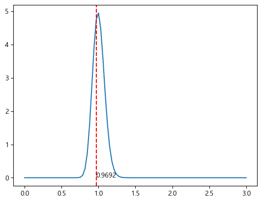

```python
plt.plot(np.linspace(0, 3, 100), f.pdf(np.linspace(0, 3, 100), dof1, dof2))
plt.axvline(F, color='red', linestyle='--')
plt.text(F, 0.01, str(F)[:6])
plt.show()
```

## Tip. 등분산일 경우 t 검정을 해봅니다.

$S_p^2 = \frac{(n_1 - 1)S_1^2 + (n_2 - 1)S_2^2}{n_1 + n_2 - 2}$ ← 통합 분산(Pooled variance)라고 합니다.

$t = \frac{\bar{X_1} - \bar{X_2}}{S_p\sqrt{1/n_1 + 1/n_2}} \sim t(n_1 + n_2 - 2)$

```python
'''
코드는 `df_prob2`라는 DataFrame을 사용하여 두 개의 통계적 가설 검정을 수행합니다.

1. `sp2_2` 계산:
   - `df_prob2` DataFrame을 `AM` 컬럼을 기준으로 그룹화한 후, `Avg` 컬럼의 분산(`var`)과 개수(`count`)를 계산합니다.
   - `assign`을 사용하여 `count`에서 1을 뺀 값을 `cntm1`이라는 새로운 컬럼으로 추가합니다.
   - `pipe`를 사용하여 `cntm1`과 `var` 컬럼의 곱의 합을 `cntm1` 컬럼의 합으로 나누어 계산합니다.
       이 결과는 그룹별 분산을 가중 평균한 값으로 볼 수 있습니다.

2. 첫 번째 t-통계량(`t1`) 계산:
   - 다시 `df_prob2` DataFrame을 `AM` 컬럼을 기준으로 그룹화한 후, `Avg` 컬럼의 평균(`mean`)과 개수(`count`)를 계산합니다.
   - `pipe`를 사용하여 다음의 계산을 수행합니다:
     - 그룹 0의 평균에서 그룹 1의 평균을 뺍니다.
     - 분모는 `sp2_2`에 각 그룹 개수의 역수를 더한 값에 제곱근을 곱하여 계산합니다.
   - 이 식은 두 그룹의 평균 차이를 비교하는 t-통계량을 계산하는 것입니다.

3. 두 번째 t-통계량(`t2`) 계산:
   - `t1`과 동일한 과정이지만, 이번에는 그룹 1의 평균에서 그룹 0의 평균을 빼는 형태로 계산합니다.
   - 이 역시 두 그룹의 평균 차이를 비교하는 t-통계량을 계산하는 것입니다.

이 코드의 전체적인 목적은 두 그룹 (`AM`이 0인 그룹과 1인 그룹)의 평균을 비교하여 t-통계량을 계산하는 것입니다.
`sp2_2`는 두 그룹의 분산을 가중 평균하여 계산한 것이고, 이를 통해 두 그룹의 평균 차이에 대한 통계적 유의성을 평가하려는 것입니다.
'''

from scipy.stats import t

df_prob2.groupby('AM')['Avg'].agg(['var', 'count'])
```

| AM | var | count |
| --- | --- | --- |
| 0 | 157.907328 | 615 |
| 1 | 153.051088 | 618 |

```python
df_prob2.groupby('AM')['Avg'].agg(['var', 'count']).assign(
    cntm1 = lambda x: x['count'] - 1
)
```

| AM | var | count | cntm1 |
| --- | --- | --- | --- |
| 0 | 157.907328 | 615 | 614 |
| 1 | 153.051088 | 618 | 617 |

```python
sp2_2 = df_prob2.groupby('AM')['Avg'].agg(['var', 'count']).assign(
    cntm1 = lambda x: x['count'] - 1
).pipe(
    lambda x: x['cntm1'].dot(x['var']) / x['cntm1'].sum()
)

sp2_2
```

```
155.47329084778724
```

```python
df_prob2.groupby('AM')['Avg'].agg(['mean', 'count']).pipe(lambda x: print(x))
```

```
          mean  count
AM
0   170.282520    615
1   164.403722    618
```

```python
t1 = df_prob2.groupby('AM')['Avg'].agg(['mean', 'count']).pipe(
    lambda x: (x.loc[0, 'mean'] - x.loc[1, 'mean']) / ((sp2_2 * (1 / x['count']).sum()) ** 0.5)
)

t2 = df_prob2.groupby('AM')['Avg'].agg(['mean', 'count']).pipe(
    lambda x: (x.loc[1, 'mean'] - x.loc[0, 'mean']) / ((sp2_2 * (1 / x['count']).sum()) ** 0.5)
)

# 양측 검장이므로 t1, t2 를 모두이용하여 통계량을 만들어 낼 수 있습니다.
# 하지만 단측 검증이라면 좌항의 표본평균 - 우항의 표본 평균 ... 기반으로 통계량을 만들어야 합니다.
dof = len(df_prob2) - 2
t1, t2, sp2_2, sp2, t.cdf(min(t1, t2), dof)
```

```
(8.277724093228105,
 -8.277724093228105,
 155.47329084778724,
 155.47329084778724,
 1.617440428199925e-16)
```

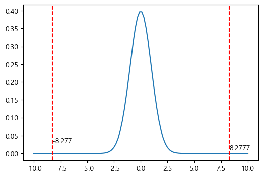

```python
'''
이 코드는 t-분포를 시각화하고, 두 그룹 간의 평균 차이에 대한 t-통계량을 강조하여 표시합니다.
이를 통해 t-통계량이 분포 내에서 어디에 위치하는지를 시각적으로 보여줍니다.

1. t-통계량(`t_stat`) 계산:
   - `t1`과 `t2` 중 작은 값을 `t_stat`로 설정합니다.
       이는 양쪽 방향의 t-통계량을 고려하여 최종적으로 하나의 t-통계량을 선택한 것입니다.
2. 플롯 크기 설정:
   - 플롯의 크기를 6x4 인치로 설정합니다.
3. t-분포 플롯:
   - -10에서 10까지 100개의 점을 사용하여 t-분포 곡선을 그립니다.
       `t.pdf`는 주어진 자유도(`dof`)에 따른 확률 밀도 함수입니다.
4. t-통계량을 표시하는 수직선 그리기:
   - t-통계량(`t_stat`) 위치에 빨간색 점선으로 수직선을 그립니다.
   - `plt.text`를 사용하여 t-통계량 값(`t_stat`)을 텍스트로 표시합니다.
       텍스트 위치는 `(t_stat, 0.03)`입니다.
5. t-통계량 왼쪽 영역 채우기:
   - `-10`에서 `t_stat`까지의 영역을 주황색으로 채웁니다.
       `t.pdf` 함수로 t-분포 값을 계산하여 y축 값으로 사용합니다.
   - 이 채움은 t-통계량 값 이하의 영역을 강조하여 유의미한 구역을 시각화합니다.
6. -t-통계량에 대한 수직선 그리기:
   - -t-통계량 위치에 빨간색 점선으로 수직선을 그립니다.
   - `plt.text`를 사용하여 -t-통계량 값을 텍스트로 표시합니다. 텍스트 위치는 `(-t_stat, 0.01)`입니다.
7. -t-통계량 오른쪽 영역 채우기:
   - `-t_stat`에서 `10`까지의 영역을 주황색으로 채웁니다.
       마찬가지로 `t.pdf` 함수로 t-분포 값을 계산하여 y축 값으로 사용합니다.
   - 이 채움은 -t-통계량 값 이상의 영역을 강조하여 유의미한 구역을 시각화합니다.

이 코드의 전체적인 목적은 t-분포 곡선을 시각화하고, 계산된 t-통계량의 위치를 강조하여 표시함으로써
통계적 검정 결과를 시각적으로 명확하게 보여주는 것입니다. t-통계량의 위치와 유의 수준에 대한 시각적 이해를 돕습니다.
'''

# pvalue에 해당하는 영역을 도식화해봅니다.
t_stat = min(t1, t2)
plt.figure(figsize=(6, 4))

plt.plot(np.linspace(-10, 10, 100), t.pdf(np.linspace(-10, 10, 100), df=dof))

plt.axvline(t_stat, color='red', linestyle='--')
plt.text(t_stat, 0.03, str(t_stat)[:6])
plt.fill_between(np.linspace(-10, t_stat, 100), np.zeros(shape=100), t.pdf(np.linspace(-10, t_stat, 100), df=dof), color='orange')

plt.axvline(-t_stat, color='red', linestyle='--')
plt.text(-t_stat, 0.01, str(-t_stat)[:6])
plt.fill_between(np.linspace(-t_stat, 10, 100), np.zeros(shape=100), t.pdf(np.linspace(-t_stat, 10, 100), df=dof), color='orange')
plt.show()
```

## 단계 2-5

단계 2-2와 2-3의 검정 결과를 바탕으로, 단계 2-4의 T-검정의

가정을 만족한다면 D 값을 1 아니면 0으로 한다. (유의 수준을 5%)

```python
D = 1 if (A >= 0.05) and (B >= 0.05) else 0
D
```

```
0
```

## 단계 2-6

오전/오후에 따라 Avg를 구분하여 Mann-Whitney U 검정을 하라. 검정 결과 pvalue을 E값으로 한다.

Mann-Whitney U 검정 : 두 독립적인 정규분포를 따르지 않는 표본들 간의 median 차이 비교

대립 가설은 '오전의 Avg와 오후의 Avg의 중앙값은 같지 않다' 입니다.

**함수가이드**

scipy.stats.mannwhitneyu, alternative를 문제 요건에 반드시 맞추어 설정합니다.

문제 지시사항 외 Default 값 사용

```python
from scipy.stats import mannwhitneyu

result_2_6 = mannwhitneyu(
    df_prob2.loc[df_prob2['AM'] == 0, 'Avg'],
    df_prob2.loc[df_prob2['AM'] == 1, 'Avg'],
    alternative='two-sided'
)

E = result_2_6.pvalue
result_2_6, E
```

```
(MannwhitneyuResult(statistic=239777.5, pvalue=1.7651446950415425e-15),
 1.7651446950415425e-15)
```

```python
from scipy.stats import mannwhitneyu

result_2_6 = mannwhitneyu(
    df_prob2.loc[df_prob2['AM'] == 1, 'Avg'],
    df_prob2.loc[df_prob2['AM'] == 0, 'Avg'],
    alternative='two-sided'
)

# 통계량은 다르지만 p-value는 동일
E = result_2_6.pvalue
result_2_6, E
```

```
(MannwhitneyuResult(statistic=140292.5, pvalue=1.7651446950415425e-15),
 1.7651446950415425e-15)
```

```python
A, B, C, D, E, A + B + C + D + E, round(A + B + C + D + E, 3)
```

```
(0.026428762823343277,
 0.043661389499902725,
 8.27772409322812,
 0,
 1.7651446950415425e-15,
 8.347814245551367,
 8.348)
```

A + B + C + D + E를 소수점 넷째 자리에서 반올림하여 셋째 자리까지 적으시오

**8.348**